# Lösungen aus *Algorithmische Methoden*

Bearbeitung der Aufgabenblätter aus der Vorlesung

Jeldo Arno Meppen

2020-12-08

# Vorbereitungen

Um alle uns gestellten Aufgaben lösen zu können, bedarf es des `import`s verschiedener Python-Bibliotheken oder Module. Für uns besonders wichtig sind `re` für *reguläre Ausdrücke*, `nltk` für *Verarbeitung natürlicher Sprache* und `matplotlib` für das Erstellen mathematischer Darstellungen wie *Graphen*.

```python
import os
import re
import nltk
from nltk.corpus import PlaintextCorpusReader
import matplotlib
```

# Aufgabenblatt 1

## Aufgabe 1.1

> Weisen Sie einer Variable die Zeichenkette `”Trier, den 3.11.2020\nMit freundliche Grüßen”` zu und geben Sie einen regulären Ausdruck an, der das vollständige Datum extrahiert. Können Sie mit dem von Ihnen gewählten regulären Ausdruck jeweils auch die Tages-, Monats- und Jahresangabe extrahieren?

```python
ort_datum = "Trier, den 3.11.2020\nMit freundliche Grüßen"
result = re.search("((\d+)[./-](\d+)[./-](\d+))", ort_datum)
# [./-] hilft bei MM/DD/YY oder YYYY-MM-DD
date = result.group(1)
day = result.group(2)
month = result.group(3)
year = result.group(4)
print(f"Heute ist der {date}, oder ISO: {year}-{month}-{day}")
# gilt nur für DDMMYY(YY)
```

```
## Heute ist der 3.11.2020, oder ISO: 2020-11-3
```

## Aufgabe 1.2

> Weisen Sie einer Variable die Zeichenkette `"Betty bought a bit of butter, But the butter was so bitter, So she bought some better butter, To make the bitter butter better."` zu und geben Sie einen regulären Ausdruck an, der alle Wörter extrahiert, die mit `"b"` oder `"B"` beginnen.

```python
rhyme = '''
Betty bought a bit of butter, But the butter was so bitter,
So she bought some better butter, To make the bitter butter better.'''
print(re.findall("[Bb]\w+", rhyme))
```

```
## ['Betty', 'bought', 'bit', 'butter', 'But', 'butter', 'bitter', 'bought', 'better', 'butter', 'bitter', 'butter', 'better']
```

## Aufgabe 1.3

> Geben Sie einen regulären Ausdruck an, der aus einem Text, der eine Email-Adresse enhält diese Email-Adresse extrahiert. Achten Sie darauf, dass Sie auch auf die user-id, die Domäne und den Suffix zugreifen können.

```python
emails = "test.acc+uni@g-mail.co.jp, notme@hey.com"
result = re.findall("(([\w\.\-]+)\+?[\w]*@([\w\-]+)(\.[\w]+\.?[\w]*))", emails)
for mail in result:
  print(mail)
```

```
## ('test.acc+uni@g-mail.co.jp', 'test.acc', 'g-mail', '.co.jp')
## ('notme@hey.com', 'notme', 'hey', '.com')
```

## Aufgabe 1.4

> Gegeben sei eine Zeichenkette, die unnötige Leerzeichen, Tabs und überflüssige Interpunktionszeichen enthält. Geben Sie einen Ausdruck an, der diese Zeichen entfernt.

```python
text = "     Dieser,     Anblick   spottet;    jeder  Beschreibung,!   "
result = re.findall("([^\s,;]+)", text)
print(*result)
```

```
## Dieser Anblick spottet jeder Beschreibung !
```

# Aufgabenblatt 2

## Aufgabe 2.1

1. Wählen Sie mindestens 4 Online-Artikel aus, die aus unterschiedlichen Zeitungsportalen stammen oder unterschiedlichen Genres zuzurechnen sind.
2. Speichern Sie diese Artikel anschließend als reine Textdateien (Kodierung: UTF-8).
3. Erzeugen Sie ein Korpus, das diese Texte enthält (PlaintextCorpusReader).

```python
corpus_dir = os.getcwd() + "/data"
corpus_texts = ".+\.txt"
mein_korpus = PlaintextCorpusReader(corpus_dir, corpus_texts, encoding='utf-8')
print(mein_korpus.fileids())
```

```
## ['biden-iraq.txt', 'bushido.txt', 'corbyn.txt', 'corona.txt', 'stoppworte.txt', 'trump.txt', 'turk.txt']
```

## Aufgabe 2.2.1

> Berechnen Sie die Länge in Token und den Vokabularumfang (Types).

```python
corpus_dict = {
    "Trump" : mein_korpus.words('trump.txt'),
    "Rapper" : mein_korpus.words('bushido.txt'),
    "Corbyn" : mein_korpus.words('corbyn.txt'),
    "Corona" : mein_korpus.words('corona.txt')
}
all = corpus_dict["Trump"]
all += corpus_dict["Rapper"]
all += corpus_dict["Corbyn"]
all += corpus_dict["Corona"]
corpus_dict.update({'Korpus' : all})
for text in corpus_dict:
    print(text + ':', '\tLänge:', len(corpus_dict[text]), '\tUmfang:', len(set(corpus_dict[text])))
```

```
## Trump:   Länge: 1285     Umfang: 545
## Rapper:  Länge: 617  Umfang: 301
## Corbyn:  Länge: 209  Umfang: 145
## Corona:  Länge: 820  Umfang: 435
## Korpus:  Länge: 2931     Umfang: 1119
```

```python
for text in corpus_dict:
    fd = nltk.FreqDist(corpus_dict[text])
    print(text + ':', fd.most_common(10), '\n')
```

```
## Trump: [(',', 74), ('.', 59), ('der', 31), ('die', 26), ('Trump', 24), ('in', 21), ('Biden', 21), ('-', 20), ('sich', 16), ('und', 16)]
##
## Rapper: [('.', 30), (',', 27), ('Bushido', 15), ('-', 14), ('der', 14), ('Abou', 13), ('Chaker', 11), ('habe', 11), ('und', 10), ('„', 8)]
##
## Corbyn: [('der', 11), (',', 9), ('.', 8), ('Corbyn', 5), ('wieder', 5), ('-', 5), ('in', 4), ('er', 3), ('Labour', 3), ('dem', 3)]
##
## Corona: [(',', 59), ('.', 36), ('die', 22), ('der', 15), ('in', 15), ('-', 14), ('?', 11), (':', 10), ('wird', 9), ('werden', 8)]
##
## Korpus: [(',', 169), ('.', 133), ('der', 71), ('die', 55), ('-', 53), ('in', 48), ('und', 35), ('zu', 30), (':', 30), ('sich', 27)]
```

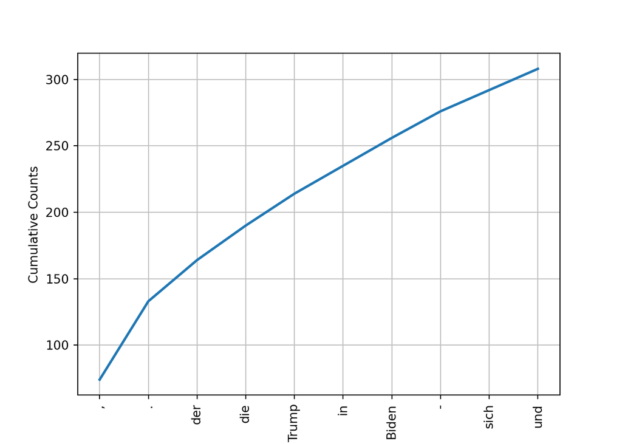

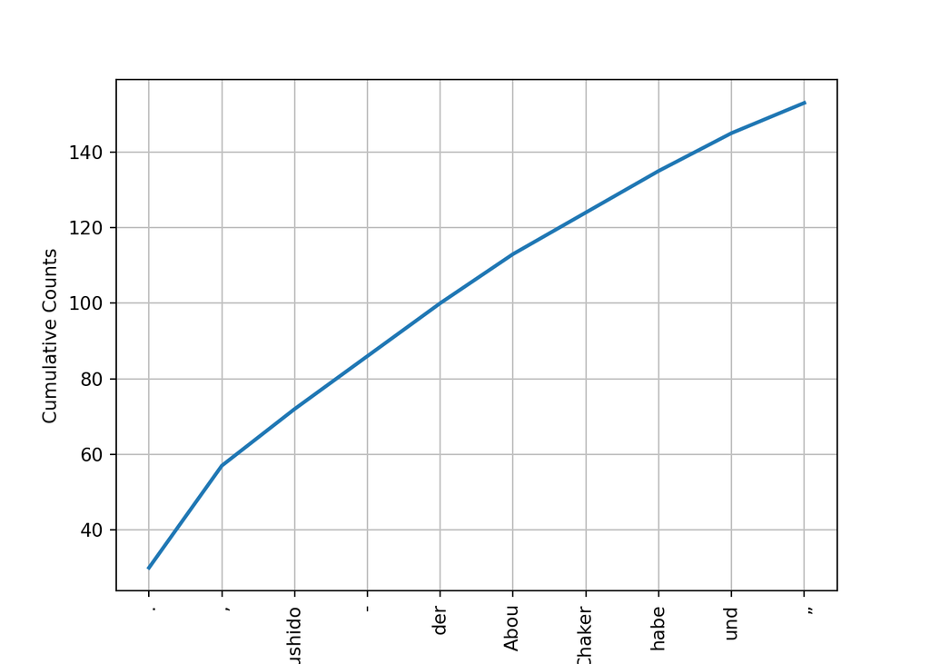

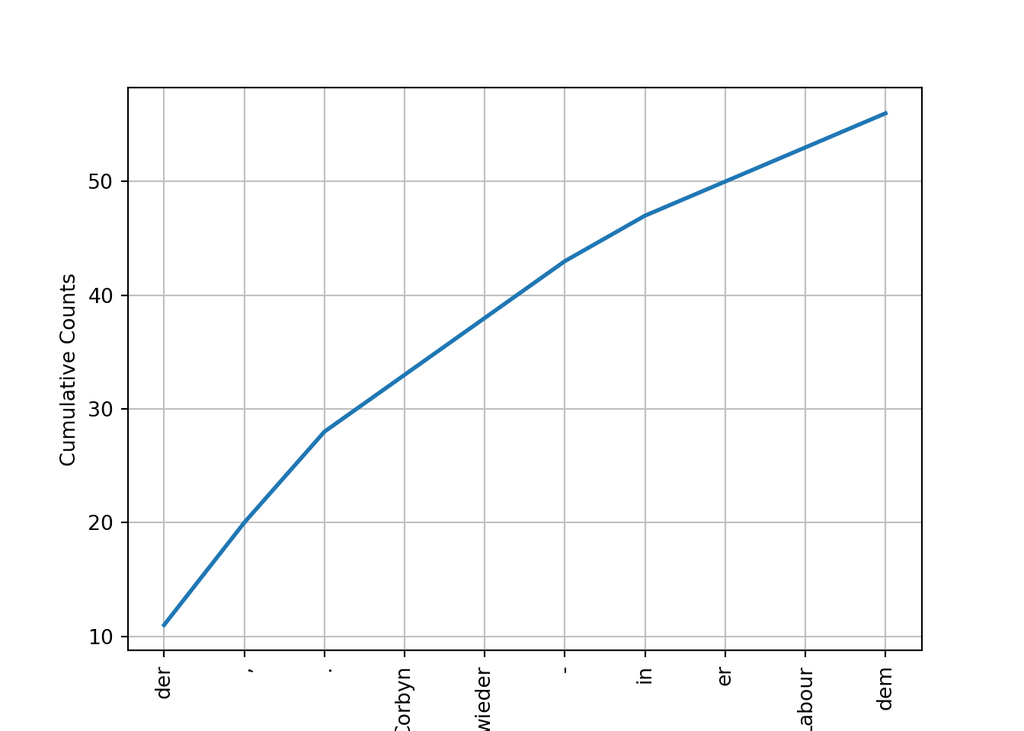

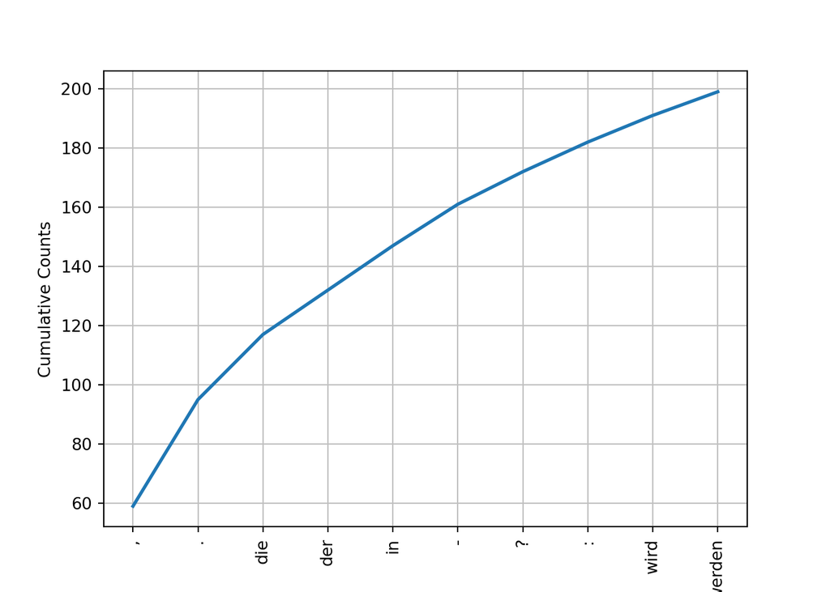

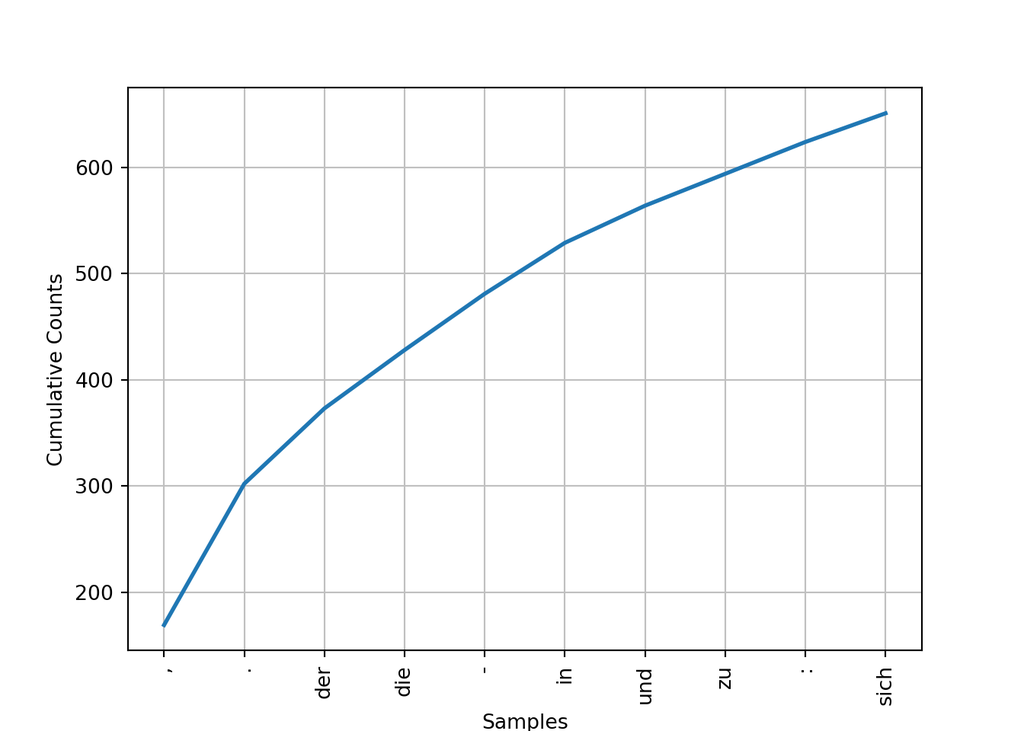

```python
for text in corpus_dict:
    fd = nltk.FreqDist(corpus_dict[text])
    print(text + ':')
    fd.plot(10, cumulative=True)
```

# Arbeitsblatt 3

## Aufgabe 3.1

## Aufgabe 3.2

## Aufgabe 3.3

# Arbeitsblatt 4

## Aufgabe 4.1

> Definieren Sie eine Funktion `stamm_erweiterung`, die einen Wortstamm $w$ und eine Liste $L$ von Wörtern/Token als Argumente nimmt und als Wert eine Liste von Wörtern aus $L$ liefert, die den Stamm $w$ enthalten.

```python
def stamm_erweiterung(wortstamm, liste):
    ergebnis = []
    for wort in liste:
        if wortstamm in wort:
            ergebnis.append(wort)
    return ergebnis
```

```python
stamm_erweiterung("impf", mein_korpus.words('corona.txt'))
```

```
## ['impfen', 'geimpft', 'geimpft', 'impft', 'impft']
```

## Aufgabe 4.2

> Definieren Sie eine Funktion sprach_identifikation, die einen Text bzw. Korpus als Argument nimmt und feststellt, in welcher Sprache er geschrieben ist. Die Funktion soll dazu die in NLTK für verschiedene Sprachen definierten Stop- wortlisten verwenden und als Wert die Sprache ausgeben, für die der Text die größte Trefferzahl (enthaltene Stopwörter) aufweist.

```python
from nltk.corpus import stopwords
```

```python
def sprach_vergleich(text, sprache):
    stopwort_treffer = []
    for wort in text:
        if wort in stopwords.words(sprache):
            stopwort_treffer.append(wort)
    return len(stopwort_treffer)
```

```python
def sprach_identifikation(text):
    treffermenge = {}
    for sprache in stopwords.fileids():
        länge = sprach_vergleich(text, sprache)
        treffermenge[sprache] = länge
    sortiert = sorted(treffermenge, key=treffermenge.get)
    return sortiert[-1]
```

```python
sprach_identifikation(mein_korpus.words('biden-iraq.txt'))
```

```
## 'english'
```

```python
sprach_identifikation(mein_korpus.words('corona.txt'))
```

```
## 'german'
```

```python
sprach_identifikation(mein_korpus.words('turk.txt'))
```

```
## 'turkish'
```